# Lab 4

Shannon Pileggi

February 6, 2018

```r
library(survival)
```

# Question 1

*Suppose a sample of 7 driers is selected and the times until failure (in years) were observed for a period of 10 years. The following times were recorded:*

`5 8 8 9 10+ 10+ 10+`

*where $+$ indicates that the event time was right censored.*

## 1a

*Compute the Kaplan-Meier estimates of survival for each complete event time. Report the estimated survival probabilities for the complete event times.*

```r
# input data
driers <- data.frame(time = c(5,8,8,9,10,10,10),
                     censor = c(1,1,1,1,0,0,0))

# create survival object
KM_obj <- survfit(Surv(time, censor) ~ 1, data = driers, conf.type = "none")

# view object
summary(KM_obj)
```

```
## Call: survfit(formula = Surv(time, censor) ~ 1, data = driers, conf.type = "none")
##
##  time n.risk n.event survival std.err
##     5      7       1    0.857   0.132
##     8      6       2    0.571   0.187
##     9      4       1    0.429   0.187
```

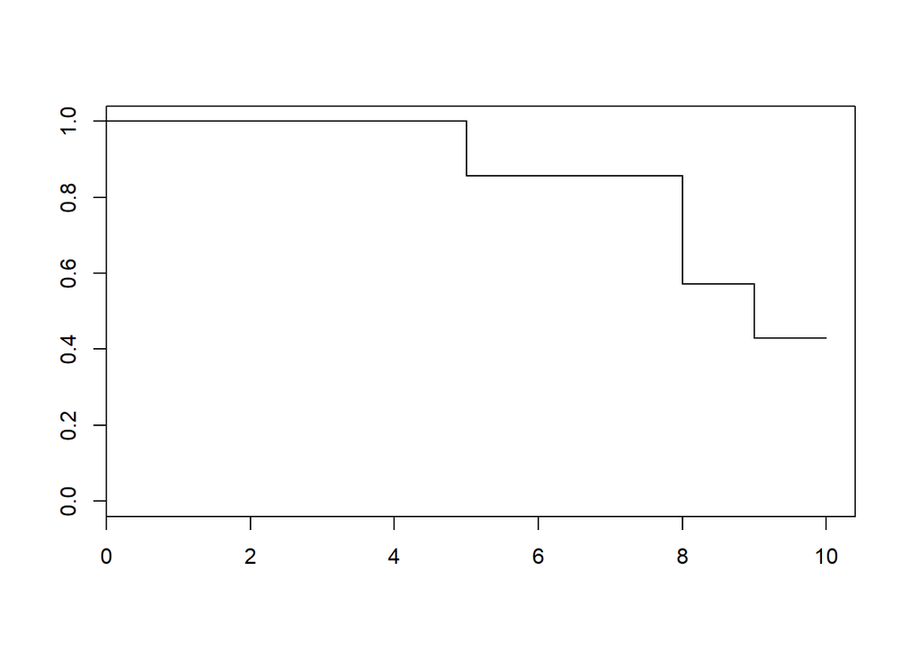

```r
# plot curve
plot(KM_obj)
```

${\hat{S}(5)=.857}$, ${\hat{S}(8)=.571}$, and ${\hat{S}(9)=.429}$

## 1b

*Estimate the probability that a drier will last longer than 6 years.*

Based on the previous output, this is $\hat{S}(6)=.857$.

## 1c

*Estimate the median time until a drier fails.*

```r
print(KM_obj)
```

```
## Call: survfit(formula = Surv(time, censor) ~ 1, data = driers, conf.type = "none")
##
##      n events median
##      7      4      9
```

$\hat{t}_{50}=9$

# Question 2

*The data set `ovarian` is available for analysis in the `survival` package. Submit `help(ovarian)` to the R console in order to examine the help file for this data set. Note that the observed event times are contained in the variable `futime` (follow-up time measured in days from administration of treatment until death), and the censoring status variable, `fustat`, takes value 0 for censored event times.*

## 2a

*Estimate the proportion of ovarian cancer patients in the study who survived longer than 275 days after treatment.*

```r
KM_obj <- survfit(Surv(futime, fustat) ~ 1,
                  data = ovarian,
                  conf.type = "plain")
summary(KM_obj)
```

```
## Call: survfit(formula = Surv(futime, fustat) ~ 1, data = ovarian, conf.type = "plain")
##
##  time n.risk n.event survival std.err lower 95% CI upper 95% CI
##    59     26       1    0.962  0.0377        0.888        1.000
##   115     25       1    0.923  0.0523        0.821        1.000
##   156     24       1    0.885  0.0627        0.762        1.000
##   268     23       1    0.846  0.0708        0.707        0.985
##   329     22       1    0.808  0.0773        0.656        0.959
##   353     21       1    0.769  0.0826        0.607        0.931
##   365     20       1    0.731  0.0870        0.560        0.901
##   431     17       1    0.688  0.0919        0.508        0.868
##   464     15       1    0.642  0.0965        0.453        0.831
##   475     14       1    0.596  0.0999        0.400        0.792
##   563     12       1    0.546  0.1032        0.344        0.749
##   638     11       1    0.497  0.1051        0.291        0.703
```

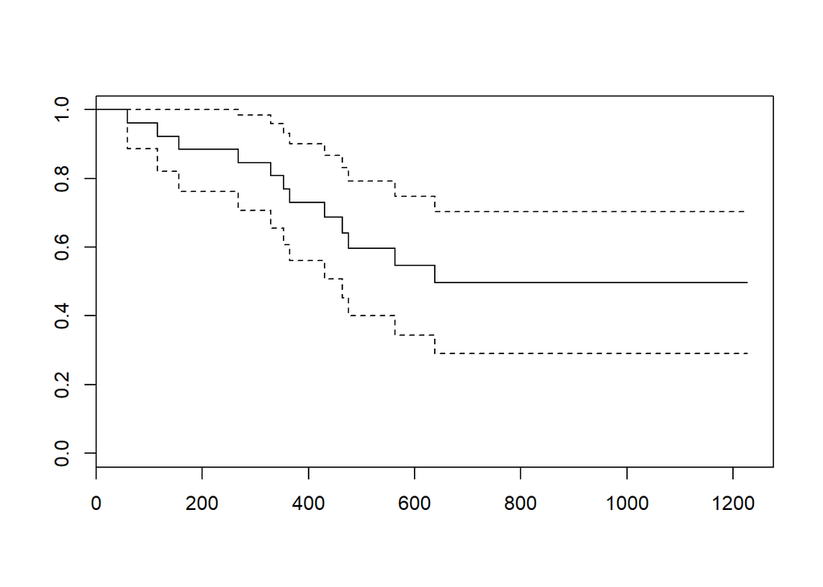

```r
plot(KM_obj)
```

$\hat{S}(275)=0.846$

## 2b

*Find and report the standard 95% confidence interval for the probability that a randomly selected ovarian cancer patient survives longer than 275 days. Interpret the interval.*

The standard 95% confidence interval for $S(275)$ is $(0.707, 0.985)$. We are 95% confident that the true probability that a randomly selected ovarian cancer patient survives beyond 275 days is between .707 and .985.

## 2c

*Find and report the 95% confidence interval for the probability that a randomly selected ovarian cancer patient survives longer than 275 days based on the $\ln(-\ln S(t))$ approach.*

```r
#log-log CI
KM_obj <- survfit(Surv(futime, fustat) ~ 1,
                  data = ovarian,
                  conf.type = "log-log")

summary(KM_obj)
```

```
## Call: survfit(formula = Surv(futime, fustat) ~ 1, data = ovarian, conf.type = "log-log")
##
##  time n.risk n.event survival std.err lower 95% CI upper 95% CI
##    59     26       1    0.962  0.0377        0.757        0.994
##   115     25       1    0.923  0.0523        0.726        0.980
##   156     24       1    0.885  0.0627        0.684        0.961
##   268     23       1    0.846  0.0708        0.640        0.939
##   329     22       1    0.808  0.0773        0.598        0.915
##   353     21       1    0.769  0.0826        0.557        0.889
##   365     20       1    0.731  0.0870        0.517        0.862
##   431     17       1    0.688  0.0919        0.471        0.830
##   464     15       1    0.642  0.0965        0.422        0.796
##   475     14       1    0.596  0.0999        0.377        0.760
##   563     12       1    0.546  0.1032        0.328        0.721
##   638     11       1    0.497  0.1051        0.282        0.679
```

The 95% confidence interval for $S(275)$ based on the $\ln(-\ln S(t))$ approach is $(0.640, 0.939)$

## 2d

*Note that the Kaplan-Meier curve does not reach 0. What does this imply about the treatment that was administered to the ovarian cancer patients?*

Treatment(s) are effective since about half the patients survive beyond the end of the study (beyond 1200 days).

# Question 3

*The text file `Graduate.txt` located on PolyLearn contains the time (in years) that 1000 students (472 males and 528 females) took to graduate (obtain a bachelor’s degree) from college (measured from the time they entered a post-secondary institution, i.e. either a junior college or four year degree granting institution). The `Gender` column contains the gender of each student, and `Censor` contains the values of the censoring status variable. Save the data file to an particular location on your computer or flash drive.*

## 3a

Read the data into `R` using whatever method you are comfortable with. If you need help, you can follow this syntax:

```r
graduate <- read.table(file = "FILE LOCATION/Graduate.txt", header = T)
```

```r
myfile <- file.path("C:", "Users", "spileggi", "Google Drive", "STAT 417", "Data sets", "Graduate.txt")
graduate <- read.table(file = myfile, header = T)
head(graduate)
```

```
##     Years Censor Gender
## 1 7.50000      0      0
## 2 3.66667      1      1
## 3 0.58333      0      0
## 4 3.66667      1      1
## 5 3.75000      1      1
## 6 4.25000      0      0
```

## 3b

*Source the `plot_haz` and `plot_chaz` functions by following the directions in the `Non-parametric survival methods in R` help file. Be sure to include the source code in an R chunk.*

```r
source("C:/Users/spileggi/Google Drive/STAT 417/plot.haz.R")
```

## 3c

*Construct the Kaplan-Meier estimated hazard function. Based on your understanding of college careers, briefly discuss the two highest peaks in the plot.*

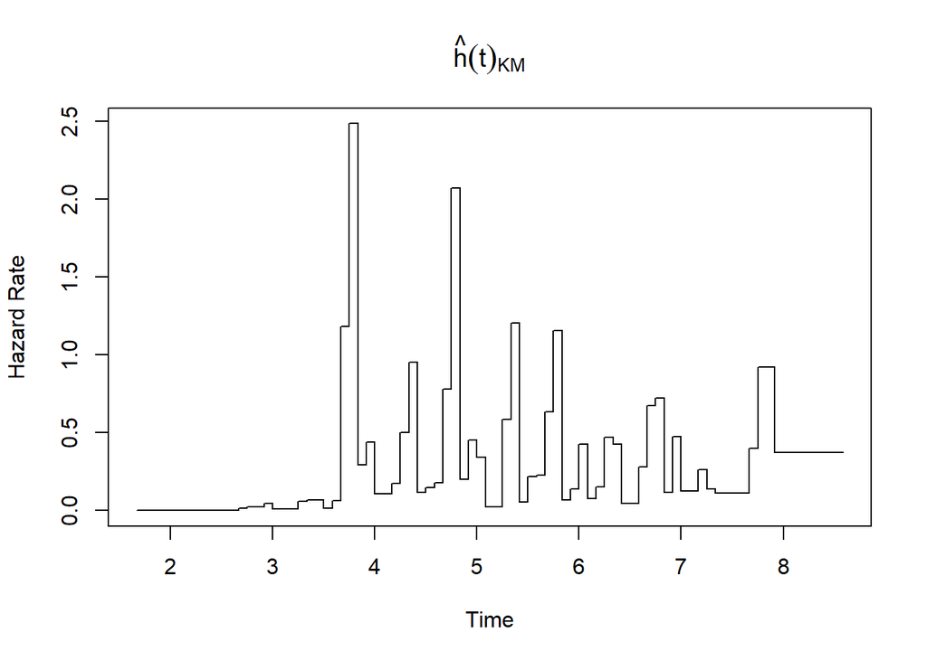

[output not shown]

```r
KM_obj <- survfit(Surv(Years, Censor) ~ 1, data = graduate)
plot_haz(KM_obj)
```

The two highest peaks correspond to when the hazard of graduating is highest, i.e. after the 4th and 5th years of college.